# Diamond pricing

2019/4/27

## Overview

This is a Shiny app to explore the diamonds dataset in **ggplot2**, and to predict the price of a diamond. It’s an updated version of a class project for [Developing Data Products](https://www.coursera.org/learn/data-products) as part of the **Data Science Specialization** on Coursera, April, 2019.

With the shiny app, reader can choose the cut and clarity variables in the boxcheck input. The webpage of the app is https://eric-yue.shinyapps.io/test/.

All of the code is listed at https://github.com/xmyyj001/diamonds_pricing.

## About the data

```
## # A tibble: 6 x 10
##   carat cut       color clarity depth table price     x     y     z
##   <dbl> <ord>     <ord> <ord>   <dbl> <dbl> <int> <dbl> <dbl> <dbl>
## 1 0.23  Ideal     E     SI2      61.5    55   326  3.95  3.98  2.43
## 2 0.21  Premium   E     SI1      59.8    61   326  3.89  3.84  2.31
## 3 0.23  Good      E     VS1      56.9    65   327  4.05  4.07  2.31
## 4 0.290 Premium   I     VS2      62.4    58   334  4.2   4.23  2.63
## 5 0.31  Good      J     SI2      63.3    58   335  4.34  4.35  2.75
## 6 0.24  Very Good J     VVS2     62.8    57   336  3.94  3.96  2.48
```

## Diamonds price with cut

First we can see that diamonds with different cut method, will be at very much variant pricing.

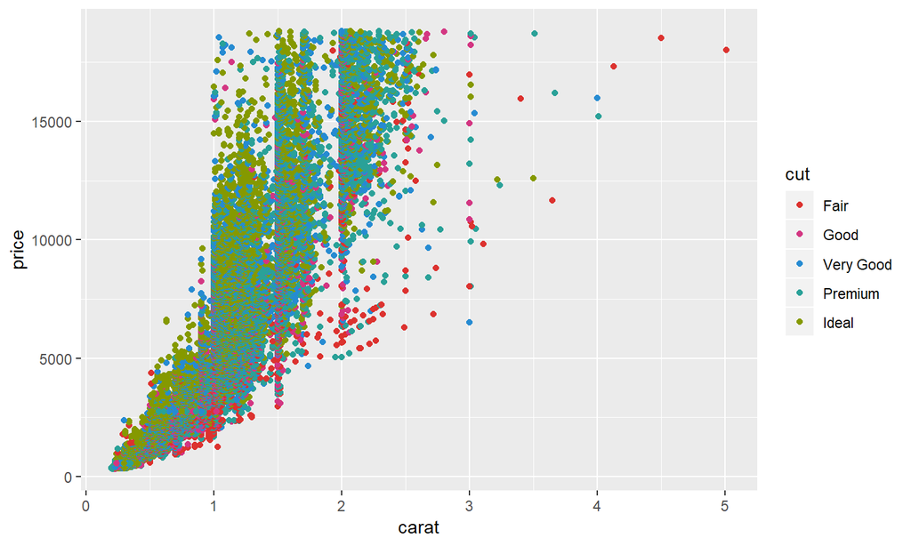

## Diamonds price with clarity

Also with the clarity property of diamonds get different price.

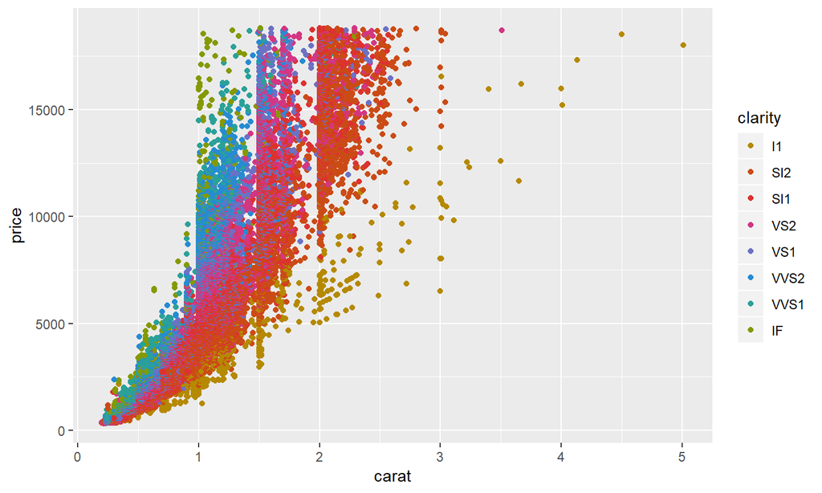

## Diamonds price with Linear regression

On my shiny app, there will give the choice of cut method and clarity property, and get according price.

Below is just an example. I have filtered the data of diamonds with condition: cut==“Good”&clarity==“SI1”, showing a linear regression line.

Applying the linear regression model, when input the cut method, clarity property and carats of the diamond, the app will predict the price accordingly.

## The plot

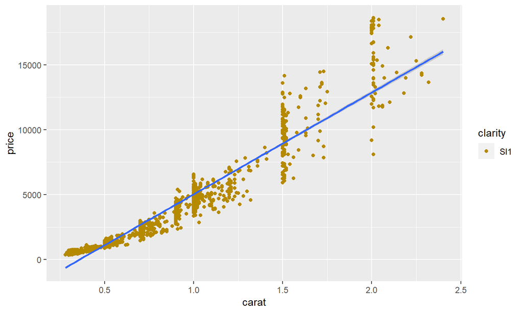